# Bumblebee Lab 13

Rachael Robinson, Manasi Raol, Brady Kiesling, William Brickowski

4/16/2019

# Lab 13

## What is the overall research question and why is it interesting/important?

Research question: How does debt to foreign countries compare to other economic indicators/factors?

This question is important because understanding debt in various parts of the world can help us better make predictions about how it will impact or be affected by other economic factors. Foreign markets are unpredictable, but having some well-known consequences of and by-products of debt could help mitigate their negative effects. Understanding how debt becomes problematic could also help illuminate behaviors and methods to reduce foreign debt and it’s byproducts.

## Brief description of the dataset(s) that you are using and any preprocessing of the data

The first dataset we are using is the debt dataset from the World Bank. This dataset encompasses public and private debt, and reports the percentage of a countries GNI which the debt makes up. The dataset shows all the countries evaluated, and the perentage GNI debt for every year. This dataset was tidied by gathering the years into their own column, where the percentage GNI for each country and year became the observation. This dataset was further tidied by parsing the years to represent numbers.

Another dataset used was aid recieved as an economic indicator. This dataset came from the World Bank and represents the aid recieved in current US dollars per person, per year, per country. The data is found by dividing the Net Official Development Assistance by the population. This dataset was tidied in an identical fashion to the debt dataset.

## Individual Subquestions

### William

Subquestion to address: Does the data suggest there there was a significant difference in the mean foreign debt among various countries in the years preceding The Great Recession (2002-2006) and the years of The Great Recession (2006-2011). If there is a significant difference in foreign debt among various countries between these two time periods, can high or low levels of foreign debt be a usefull indicator in predicting a coming recession? Additionally, can we perform regression to predict when other economic factors lead to higher levels or lower levels of debt so that we can avoid whichever (high or low levels of debt) contribute to economic recessions?

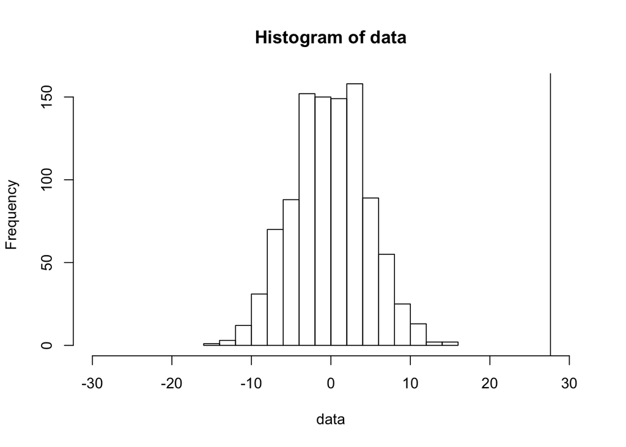

Here, I call my Permutation-Testing function with the foreign debt values between 2002-2011 as well as the number of data entries for just the years preceding The Great Recession which are from 2002-2006. I then generate a histogram with the returned vector of means from the Permutation-Testing function to examine its distribution. I also add an abline line corresponding to the value of our test statistic which is the difference in the sample mean for foreign debt between the following two time periods: 2002-2006 and 2006-2011.

Based on the above histogram, it is clear that the test statistic for the mean debt as a percentage of GNI during preceding The Great Recession is significantly different than the mean debt during the ensuing recession called The Great Recession. Debt was significantly higher during the preceding boom, according to the test statistic of the mean difference in debt between the two time periods. This makes sense because The Great Recession was an economic meltdown that was caused by high leverage in the United States and around the word. After The Great Recession, much debt went into default which reduced the amount of debt around the world. Additionally, many financial institutions around the world became far more strict about giving out easy credit.

Because our test statistic is in the 100th percentile of the data, for it lies beyond the largest value on the histogram, we can reject the Null Hypothesis of our mean permutation test which states that the means between the two test groups are the same. In this case, the two test groups were the levels of foreign debt in the previously describe two time periods. Because we rejected the null, it is clear that the levels of debt between these two time periods were in fact different.

```
##
## Call:
## lm(formula = debt_percent_GNI ~ discount_rate + exports + imports +
##     inflation + primary_completion, data = aggregate)
##
## Residuals:
##     Min      1Q  Median      3Q     Max
## -5.0213 -0.4114 -0.1005  0.2230 12.4590
##
## Coefficients:
##                      Estimate Std. Error t value Pr(>|t|)
## (Intercept)        -3.154e-17  2.560e-02   0.000    1.000
## discount_rate       3.371e-03  2.863e-02   0.118    0.906
## exports             5.952e-02  4.481e-02   1.328    0.184
## imports             2.419e-01  4.202e-02   5.756 1.07e-08 ***
## inflation           2.409e-01  2.856e-02   8.435  < 2e-16 ***
## primary_completion -1.340e-01  2.886e-02  -4.644 3.76e-06 ***
## ---
## Signif. codes:  0 '***' 0.001 '**' 0.01 '*' 0.05 '.' 0.1 ' ' 1
##
## Residual standard error: 0.932 on 1319 degrees of freedom
## Multiple R-squared:  0.1347, Adjusted R-squared:  0.1315
## F-statistic: 41.08 on 5 and 1319 DF,  p-value: < 2.2e-16
```

Based on our understanding that debt was significantly higher preceding The Great Recession, I would like to regress various marco economic factors against debt as the response so that countries and institutions world wide can better predict what factors lead to high levels of debt so as to be able to predict recessions that may ensue as occured with The Great Recession.

Based on these results, we can better understand that factors the impact foreign debt. Foreign debt was clearly at different levels during and preceding The Great Recession. Foreign debt levels were significantly higher preceding The Great Recession. The may suggest that increased levels of foreign debt may be a good way to predict a coming recession. To prevent recessions, we may be able to mitigate debt by understanding the predictors that result in heightened levels of foreign debt that we derived in our regression analysis.

### Rachael

Subquestion to address: Is there a difference in the mean foreign debt between countries that recieve a high amount of foreign aid versus a low amount?

This subquestion contributes to the group question, because it is a relevant economic question to the developing world. Intuitions suggests that if a country recieves a high amount of foreign aid, it’s foreign debt should be mitigated, or maybe nonexistent altogether. However, literature has indicated that the opposite is actually true, and foreign aid initiatives often correlate to higher amounts of debt owed to the same foreign entities. In this way, this subquestion tackles some of the more subtle ways in which debt can play a role in the developing world. It contributes to the team question because it shows a factor which can change the economies of the world.

My unique function takes in a value and a median. The function then performs a comparison to see where the value falls in terms of the median. The function then saves into it’s output list whether the value is “high” or “low”. Low would be below the median, where high would be equal to or above.

My map function then implements my unique function to help me create my testing groups for the permutation test. My map function takes all the values of aid recieved in the data set, along with the median of that same variable. The map function calls the high_low function for each value in the vector, and creates a list, aid_level, which shows whether the aid recieved by each country, each year, is considered “high” aid or “low” aid.

After incorporating the list created by the map function back into my main dataframe, I could then perform my permutation test with the two groups I created, high aid and low aid.

Permutation testing:

1- The null hypothesis in this case is that the average debt of low aid recievers will be equal to that of high aid recievers. The alternative is two-sided and assumes that there is a difference in mean debt between the two groups.

2- The test statistic I am using is the true difference in mean debt between the two groups: high aid recieved and low aid recieved.

3- Histogram of distribution of test statistic, and real test statistic

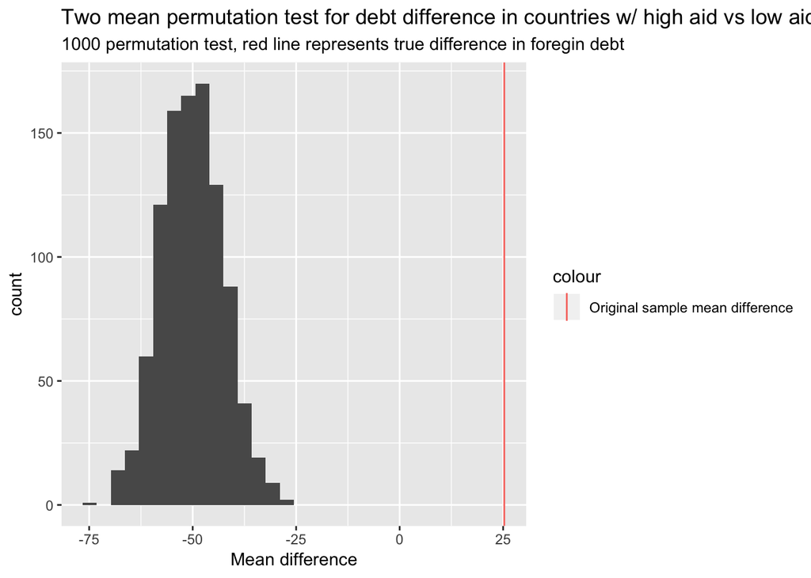

4- Percentile calculation

```
## [1] 1
```

7- Conclusion: Because our test statistic is in the 100th percentile, and is so far away from the distribution of the test statistic, I can safely reject the null and assume that there is a statistically significant difference in debt owed from places where foreign aid is high versus places where foreign aid is low.

Data-based conclusion: Due to the results of the permutation test, as well as the calculated percentiles, I will conclude that there is a signficant difference in the foreign debt between countries with high and low foreign aid. Looking at the datasets at hand, we were also able to calculate the true difference between the debts of the two groups.

```
## [1] 25.28023
```

The above caluclation shows that in the years and places where there is high aid, the debt is on average, 25.2% more of the GNI. This, compared to the distribution of the test statistic, shows that countries with high aid are more likely to also have more debt to foreign countries.